# 2025년 06월 09일 월요일 (30일차)

30일차가 된 오늘... 이제는 하나도 이해가 안가려는 느낌이 난다.  
코드가 너무너무 어려워졌다.  
힘들다.

# 📜 목차

- 자료구조 stack - 후위표기식 문제풀기
- 자료구조 tree (매우 어려움)
  - 이진트리와 순회 방법
  - 배열로 이진트리 표현하기
  - 연결 리스트로 이진트리 표현하기
    - class - (전위 순회 preorder / 중위 순회 inorder / 후위 순회 postorder)
    - class - node를 추가하는 친구 만들기

# 🟩 자료구조 stack - 후위표기식 문제풀기

## 🟢 stack class 재활용

```python
class MyStack:
    def __init__(self, size=10):
        if size < 10:
            self.size = 10
        else :
            self.size = size
        self.stack = []
        for i in range(0, self.size):
            self.stack.append(0)
        self.top = -1

    def is_full(self):
        if self.size-1 == self.top:
            return True
        return False

    def is_empty(self):
        if self.top == -1:
            return True
        return False

    def push(self, data):
        if self.is_full():
            print('이미 가득 참')
            return
        self.top += 1
        self.stack[self.top] = data

    def pop(self):
        if self.is_empty():
            return None
        item = self.stack[self.top]
        self.top -= 1
        return item

    def peek(self):
        if self.is_empty():
            return None
        return self.stack[self.top]

    def print(self):
        i = 0
        while i <= self.top:
            print(self.stack[i], end=" ")
            i+=1
        print()
```

## 🟢 후위표기식 문제 풀기

4 + 2 * 7 - 3 * 2 + 9  
이것을 후위표기식으로 만드시오~

4 + (2 * 7) - (3 * 2) + 9

### 🔄 후위 표기식으로 변환 순서

```
    2 * 7                 →     2 7 *
    4 + (2 * 7)           →     4 2 7 * +
    3 * 2                 →     3 2 *
    4 2 7 * + - (3 2 *)   →     4 2 7 * + 3 2 * -
        (진짜 앞에서만 먼저 생각해야하는구나)
    + 9                   →     4 2 7 * + 3 2 * - 9 +

    <최종 후위 표기식>
    4 2 7 * + 3 2 * - 9 +
```

### 🟡 같이 풀어보기

- 토큰화 : 숫자, 연산자, 관로로 분해
- 왼쪽부터 차례로 토큰 처리
- 숫자 > 출력 큐에 바로 추가
- 왼쪽 괄호( > 연ㅈ산자 스택에 push
- 오른쪽 괄호) > (를 만날 때까지 연사자 pop하여 출력 큐에 추가
- 연산자 > 스택의 top연산자와 우선순위 비교:
  - 낮거나 같으면 pop하여 출력 큐에 추가
  - 이후 현재 연산자 push
  - 입력이 끝난 후, 스택에 남은 연산자를 출력 큐에 순서대로 pop

### ???

나는 왜 못 풀었을까?? 이해의 문제인가???

```python
# from stack import MyStack

# infix 수식을 받아서 postfix수식으로 전환하여 반환하는 함수

# 수식 중 연산자인지 확인하는 함수
def is_operator(c):
    return c in "+-*/"  # +, -, *, / 중 하나인지 확인

# 공백 문자인지 확인하는 함수  (사용하지 않음)
# def is_space(c):
#     return c == " "  # 문자열이 공백 한 개와 같은지 확인

# 연산자의 우선순위를 반환하는 함수
def get_priority(c):
    if c in "+-":
        return 1  # +, -의 우선순위는 1
    elif c in "*/":
        return 2  # *, /의 우선순위는 2 (더 높음)
    else:
        return 0  # 연산자가 아니면 우선순위 없음


# =======================================================

# 중위표기식을 후위표기식(Postfix)으로 변환하는 함수
def postfix(expr):
    stack = MyStack()  # 연산자를 담기 위한 스택 생성
    result = ""        # 후위표기식 결과를 담을 문자열

    # 중위표기식의 각 문자(s)를 하나씩 순회
    for s in expr:

        # 1. 피연산자인 경우: 숫자일 경우 결과 문자열에 바로 추가
        if s.isdigit():
            result += s  # 숫자는 그대로 출력

        # 2. 연산자인 경우
        elif is_operator(s):
            result += " "  # 숫자와 연산자 사이를 구분해주기 위한 공백 추가

            # 스택이 비어있지 않고, 스택의 top에 있는 연산자의 우선순위가
            # 현재 연산자보다 크거나 같으면, 스택에서 pop해서 결과에 추가
            while not stack.is_empty() and \
                    get_priority(stack.peek()) >= get_priority(s):
                result = result + " " + stack.pop()

            # 현재 연산자를 스택에 push
            stack.push(s)

        # 3. 공백이나 기타 문자는 그대로 추가 (이 부분은 후속 개선 필요)
        else:
            result += s

    # 4. 모든 문자를 순회한 뒤에도 스택에 남은 연산자가 있다면 모두 pop해서 결과에 추가
    while not stack.is_empty():
        result += " " + stack.pop()

    return result  # 후위표기식 결과 반환

# 테스트: 중위표기식 '37*5+2'을 후위표기식으로 변환
print(postfix('37*5+2'))  # 결과: '37 5 * 2 +'
```

```
37 5  *2 +
```

### 🟡 이런 코드를 왜 만드는 것일까?

사람처럼 수식을 이해하지 못하는 컴퓨터에게 계산을 시키기 위한 전처리 도구

| 사용처 | 설명 |
| --- | --- |
| 🧠 계산기 앱 | 사용자 입력을 중위 → 후위로 바꾼 뒤 계산 |
| 🧮 컴파일러 | 수식을 해석해서 기계가 실행 가능한 코드로 바꿈 |
| 📚 알고리즘 문제 | 스택, 연산 우선순위, 파서 구현 등에 꼭 필요 |
| 🔐 수식 분석 | AI가 수식을 이해할 때도 이런 파싱이 필요함 |

# 🟩 Tree

[참고한 사이트](https://wikidocs.net/193817)

족보의 가계도나 조직도를 떠올리면 된다. 또는 마인드맵을 생각하자.  
어려운 말로는 그래프(graph)의 한 형태로서, 순환(cycle)이 없는 연결 그래프라 한다.

- 노드(Node): 트리를 구성하는 기본 요소, 값(key or data)과 하위 노드를 가리키는 포인터(pointer)를 가진다.
- 간선(Edge): 노드와 노드를 연결한 선 (link)

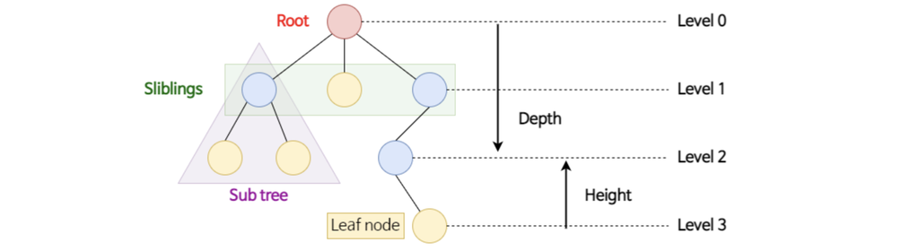

- 그림처럼 트리는 루트(Root)에서 시작한다.
  - 루트: 부모 노드가 없는 최상위 노드. 모든 트리의 루트는 하나다.
  - 부모(parent) 노드: 자식(child) 노드를 가진 노드
  - 자식(child) 노드: 부모 노드의 하위 노드
  - 형제(siblings) 노드: 부모가 같은 노드
  - 리프(leaf) 노드: 자식이 없는 노드
  - 서브 트리(sub tree): 특정 노드를 루트로 생각할 때 그 노드로부터 만들어지는 트리
- 기타 용어
  - 크기(size): 자신을 포함한 모든 자식 노드의 개수
  - 레벨(level): 루트 노드부터 특정 노드까지 연결된 간선의 수
  - 깊이(depth): 루트 노드부터 특정 노드까지의 거리, 수치로만 보면 레벨과 같은 것 같다.
  - 높이(height): 특정 노드에서 가장 깊은 노드까지의 길이
  - 경로(path): 한 노드에서 다른 노드로 갈 때 거쳐 가는 노드들의 순서
  - 차수(degree): 자식의 개수

## 🟢 이진트리와 순회 방법

이진트리(binary tree)는 아래 그림처럼 모든 노드가 두 개 이하의 자식 노드를 가지는 트리다.

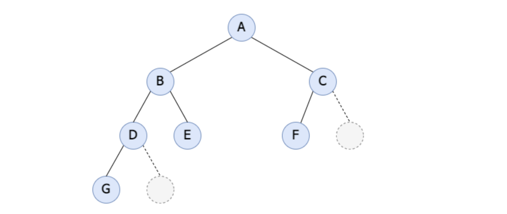

### 🟡 전위 순회(Preorder traversal)

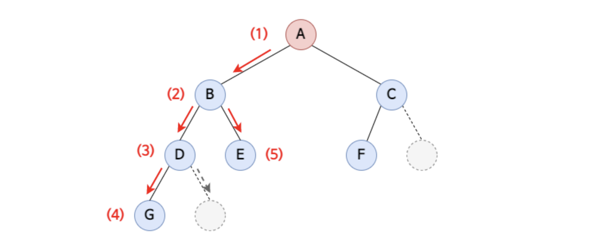

preorder - node -> left - right  
DLR  
A ➡️ B ➡️ D ➡️ G ➡️ E ➡️ C ➡️ F

### 🟡 중위 순회(Inorder traversal)

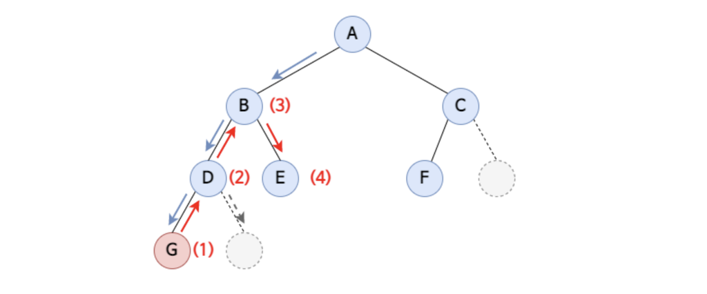

- 먼저 루트 A에서 출발한다. A를 방문하기 전에 왼쪽 B를 먼저 방문해야 한다.
- B-D-E도 서브 트리이므로 B를 방문하기 전에 B의 왼쪽을 먼저 방문해야 한다.
  - 이 과정을 반복하면 가장 먼저 방문하는 노드는 G이다.
  - D의 왼쪽을 모두 방문했으니, D를 방문하고 D의 오른쪽으로 간다.
  - D의 오른쪽은 없으므로, B의 왼쪽인 G-D를 모두 방문했다.
  - 그러므로 B를 방문한다. 그리고 B의 오른쪽 노드 E를 방문한다.
  - 이렇게 하면 A의 왼쪽인 G-D-B-E를 모두 방문했다.
- 그러므로 A를 방문한다. 이제 A의 오른쪽으로 간다.
  - 마찬가지로 C를 방문하기 전에 C의 왼쪽 F를 먼저 방문한다.
  - 마지막으로 C를 방문한다.

따라서 순회 결과는 G → D → B → E → A → F → C

### 🟡 후위 순회(Postorder traversal)

왼쪽 노드를 먼저 방문한다. 그리고 오른쪽 노드와 현재 노드를 차례로 방문한다.

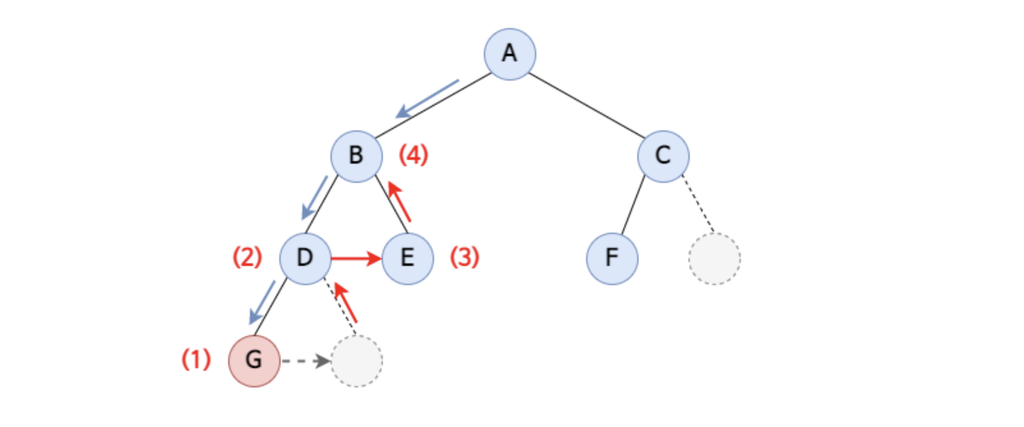

### 🟡 레벨 순서 순회(Level order traversal)

루트에서부터 레벨 순서대로 왼쪽에서 오른쪽으로 방문한다.

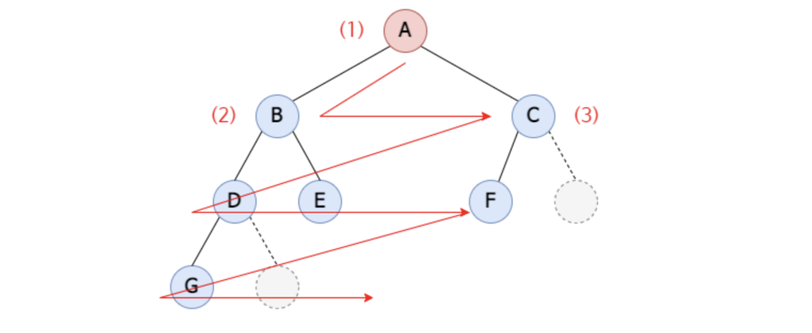

따라서 순회 결과는 A → B → C → D → E → F → G

### 🟡 이진트리와 순회 방법 - 문제 풀어보기

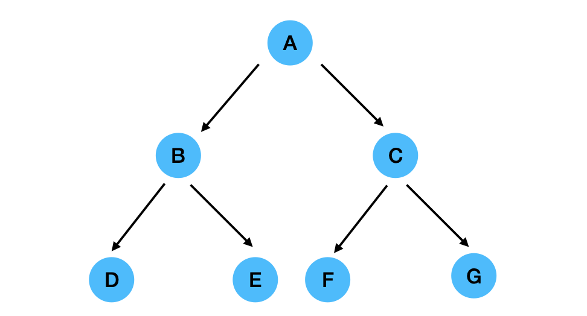

#### 전위 순회 preorder

(순서대로 왼쪽 쫙 방문하고, 나머지 오른쪽 방문하고  
right로 넘어와서 왼쪽 쫙 방문하고, 나머지 오른쪽 방문함)  
A B D E C F G

#### 중위 순회 inorder

(왼쪽으로 맨 아래로 들어감)  
D B E A F C G

#### 후위 순회 postorder

(왼쪽 맨 아래로 들어가서 오른쪽 노드 확인하고 올라오는 방식)  
D E B F G C A (A 가 마지막이다.)

## 🟢 배열로 이진트리 표현하기

파이썬에서 이진트리를 표현하는 방법에는 크게 두 가지가 있다. 그 중 하나는 배열을 이용하는 방식이다.  
이 방법은 트리의 각 노드를 배열의 인덱스로 나타내는 방식으로, 트리 구조를 쉽게 저장하고 접근할 수 있다.

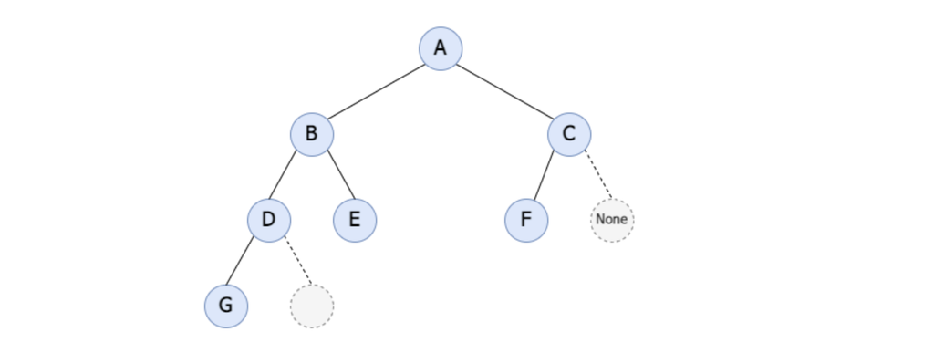

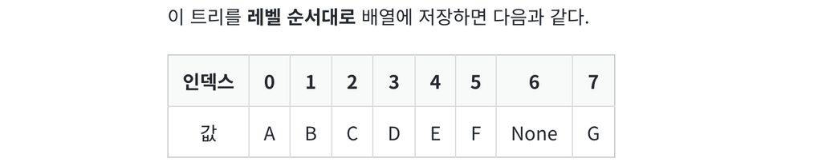

## 🟢 연결 리스트로 이진트리 표현하기

### 🟡 class - (전위 순회 preorder / 중위 순회 inorder / 후위 순회 postorder)

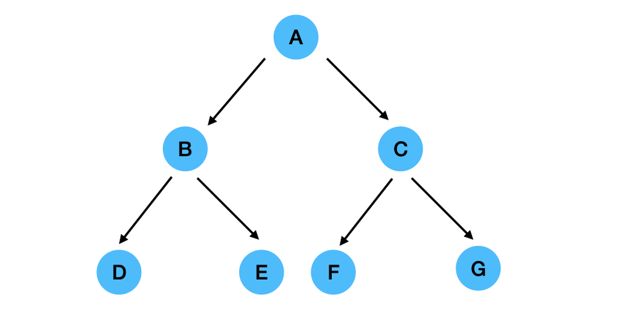

```python
from collections import deque

class TreeNode:
  def __init__(self, data=None):
    self.left = None
    self.data = data
    self.right = None
    # self.edge = []


def inorder(node):
  if node:   # "None이 아니라면.."의 의미
    inorder(node.left)
    print(node.data, end="\t")
    inorder(node.right)

def preorder(node):
  if node:   # "None이 아니라면.."의 의미
    print(node.data, end="\t")
    preorder(node.left)
    preorder(node.right)

def postorder(node):
  if node:   # "None이 아니라면.."의 의미
    postorder(node.left)
    postorder(node.right)
    print(node.data, end="\t")

'''
queue를 이용한 levelorder - 너비우선탐색
1. 큐를 초기화한다. 데큐를 써도 된다.
2. 무조건 큐에 node를 집어넣고
3. 큐가 비어있지 않는 동안 동작을 반복한다.
  3-1. 큐로부터 node 하나를 가져온다.
  3-2. 데이터를 출력한다.
  3-3. 가지고 온 노드의 left가 None이 아니면 큐에 넣는다.
  3-4. 가지고 온 노드의 right가 None이 아니면 쿠에 넣는다.
'''
def levelorder(node):
  queue = deque()  # 큐를 하나 만든다... 나는 왜 안되지?
  queue.appendleft(node)  # root

  while len(queue) != 0:  # 큐가 empty일 때까지
    current = queue.pop()
    print(current.data, end="\t")
    if current.left != None:
      queue.appendleft( current.left )
    if current.right != None:
      queue.appendleft( current.right )


# 이런 형태로 만들 수 있습니다.
if __name__ == "__main__":
  root = TreeNode("A")
  root.left = TreeNode("B")
  root.right = TreeNode("C")
  root.left.left = TreeNode("D")
  root.left.right = TreeNode("E")
  root.right.left = TreeNode("F")
  root.right.right = TreeNode("G")

  print("preorder : ", end='\t')
  preorder(root)
  print()

  print("inorder : ", end='\t')
  inorder(root)
  print()

  print("postorder : ", end='\t')
  postorder(root)
  print()

  print("levelorder : ", end='\t')
  levelorder(root)
  print()



# 스택이나 큐, 시스템이 제공하는 큐를 쓰자 - 재귀호출

# #### 전위 순회 preorder
# (순서대로 왼쪽 쫙 방문하고, 나머지 오른쪽 방문하고
#   right로 넘어와서 왼쪽 쫙 방문하고, 나머지 오른쪽 방문함)
# A B D E    C F G

# #### 중위 순회 inorder
# (왼쪽으로 맨 아래로 들어감)
# D B E A     F C G

# #### 후위 순회 postorder
# (왼쪽 맨 아래로 들어가서 오른쪽 노드 확인하고 올라오는 방식)
# D E B   F G C A
```

```
preorder : 	A	B	D	E	C	F	G
inorder : 	D	B	E	A	F	C	G
postorder : 	D	E	B	F	G	C	A
levelorder : 	A	B	C	D	E	F	G
```

### 🟡 class - node를 추가하는 친구 만들기

- levelorder() 함수 만들기
- addNode() 함수 만들기
- makeTree1() 함수 만들기
- makeTree2() 함수 만들기

```python
from collections import deque

class TreeNode:
  def __init__(self, data=None):
    self.left = None
    self.data = data
    self.right = None
    # self.edge = []


def inorder(node):
  if node:   # "None이 아니라면.."의 의미
    inorder(node.left)
    print(node.data, end="\t")
    inorder(node.right)

def preorder(node):
  if node:   # "None이 아니라면.."의 의미
    print(node.data, end="\t")
    preorder(node.left)
    preorder(node.right)

def postorder(node):
  if node:   # "None이 아니라면.."의 의미
    postorder(node.left)
    postorder(node.right)
    print(node.data, end="\t")

'''
< 알고리즘 설명 > 직접 levelorder를 만들어보세요.
queue를 이용한 levelorder - 너비우선탐색
1. 큐를 초기화한다. 데큐를 써도 된다.
2. 무조건 큐에 node를 집어넣고
3. 큐가 비어있지 않는 동안 동작을 반복한다.
  3-1. 큐로부터 node 하나를 가져온다.
  3-2. 데이터를 출력한다.
  3-3. 가지고 온 노드의 left가 None이 아니면 큐에 넣는다.
  3-4. 가지고 온 노드의 right가 None이 아니면 쿠에 넣는다.
'''
def levelorder(node):
  queue = deque()  # 큐를 하나 만든다... 나는 왜 안되지?
  queue.appendleft(node)  # root

  while len(queue) != 0:  # 큐가 empty일 때까지
    current = queue.pop()
    print(current.data, end="\t")
    if current.left != None:
      queue.appendleft( current.left )
    if current.right != None:
      queue.appendleft( current.right )





# ==========================================================================
# def addNode : 부모 노드와 원하는 방향을 부여하고 데이터를 주면 그 위치에 노드를 추가하는 함수
# bLeft 값이 True이면 왼쪽으로 붙이고, False면 오른쪽으로 붙이려고 합니다.

root = None # 이렇게 밖에 있다고 해보자!  객체지향 class의 필요성을 알 수 있다.

def addNode(parent=None, left=True, data=None):
    global root   # 전역변수, 함수 외부에서 변수에 접근 불가능

    temp = TreeNode(data)
    if parent == None:
      root = temp
    else:
      if left:
          parent.left = temp
      else:
          parent.right = temp

    return temp


def makeTree1():
  root = addNode(None, True, data="A")  #parant 값을 안주면 default로 None이 들어가기 때문에 얘가 root가 됩니다.

  level1 = addNode(root, True, "B")
  level2 = addNode(root, False, "C")

  addNode(level1, True, "D")
  addNode(level1, False, "E")

  addNode(level2, True, "F")
  addNode(level2, False, "G")



'''
< 알고리즘 설명 >
1. 큐 만들기
2. 큐에 root 노드 추가
3. 추가될 위치 찾기 - 낑겨들어갈 위치 찾기
  1. 큐에서 하나 가져온다.
  2. 갸져온 노드의 left가 None이면 여기에 추가하고 종료 / None이 아니면 left 값을 다시 큐에 넣는다.
  3. 가져온 노드의 right가 None이면 여기에 추가하고 종료 / None이 아니면 right값을 다시 큐에 넣는다.
4. 모든 요소가 추가될 때까지 1번,2번,3번을 반복한다.
'''
# makeTree2("ABCDEFGHIJK")
def makeTree2(simbol):
  global root   # 전역변수, 함수 외부에서 변수에 접근 불가능

  for c in simbol:
    q = deque()     # 큐만들기

    # if root == None:
    #   root = addNode(c)
    #   continue # else 안쓰고, contune문 만나면 아래 코드들을 건너뛰고, 다시 for문 실행함.

    q.appendleft(root)

    # 내가 추가될 때까지
    append = False
    while not append:
      node = q.pop()
      if node.left == None:
        addNode(node, True, c)
        append = True
      elif node.right == None:
        addNode(node, False, c)
        append = True
      else:
        q.appendleft(node.left)
        q.appendleft(node.right)





# ==========================================================================
# 이런 형태로 만들 수 있습니다.
if __name__ == "__main__":
  # root = TreeNode("A")
  # root.left = TreeNode("B")
  # root.right = TreeNode("C")
  # root.left.left = TreeNode("D")
  # root.left.right = TreeNode("E")
  # root.right.left = TreeNode("F")
  # root.right.right = TreeNode("G")

  makeTree1()
  makeTree2("ABCDEFGHIJK")

  print("preorder : ", end='\t')
  preorder(root)
  print()

  print("inorder : ", end='\t')
  inorder(root)
  print()

  print("postorder : ", end='\t')
  postorder(root)
  print()

  print("levelorder : ", end='\t')
  levelorder(root)
  print()
```

```
preorder : 	A	B	D	A	I	J	B	K	E	C	D	C	F	E	F	G	G	H
inorder : 	I	A	J	D	K	B	B	C	E	D	A	E	F	F	C	G	G	H
postorder : 	I	J	A	K	B	D	C	D	E	B	E	F	F	G	H	G	C	A
levelorder : 	A	B	C	D	E	F	G	A	B	C	D	E	F	G	H	I	J	K
```

# 🟩 stack 문제 - 자신보다 큰 원소 찾기

### 🟡 이중 반복문으로 풀기

- 인덱스 i는 0부터 n-1까지 반복
  - nge(다음으로 큰 원소)를 -1로 초기화
  - 인덱스 j는 i+1부터 n-1까지 반복
    - 인덱스 j의 원소가 인덱스 i의 원소보다 크면
    - nge에 인덱스 j의 원소를 대입
    - 반복문을 벗어난다.
  - 현재 원소와 nge를 출력한다.

### 🟡 스택을 사용하여 풀기

- 알고리즘 제시
  - 스택을 빈 상태로 초기화한다.
  - 가장 오른쪽에 있는 7부터 시작한다. 스택이 비었으므로, 비교할 값이 없다. 7의 nge는 -1이다. 7을 스택에 push한다.
  - 3을 스택에 저장된 7과 비교한다. 7이 크므로 3의 nge는 7이다. 그리고 3을 스택에 저장한다.
  - 5를 스택에 저장된 7, 3과 비교한다. 가장 마지막에 저장된 3은 5보다 작으므로 pop한다.
  - 그다음 값인 7과 비교한다. 7이 크므로 5의 nge는 7이다. 이제 5를 스택에 저장한다.
  - 4는 스택에 저장된 7, 5와 역순으로 비교하면 4의 nge는 5이다.

```python
class MyStack:
    def __init__(self, size=10):
        if size < 10:
            self.size = 10
        else :
            self.size = size

        self.stack = []
        for i in range(0, self.size):
            self.stack.append(0)

        self.top = -1

    def is_full(self):
        if self.size-1 == self.top:

            return True
        return False

    def is_empty(self):
        if self.top == -1:
            return True
        return False

    def push(self, data):
        if self.is_full():
            print('이미 가득 참')
            return
        self.top += 1
        self.stack[self.top] = data

    def pop(self):
        if self.is_empty():
            return None
        item = self.stack[self.top]
        self.top -= 1
        return item

    def peek(self):
        if self.is_empty():
            return None
        return self.stack[self.top]

    def print(self):
        i = 0
        while i <= self.top:
            print(self.stack[i], end=" ")
            i+=1
        print()
```

```python
def find_nge(arr: list[int]) -> list[int]:
    n: int = len(arr)
    s: list[int] = []
    res: list[int] = [-1] * n
    for i in range(n-1, -1, -1):
        while s:
            if s[-1] > arr[i]:
                res[i] = s[-1]
                break
            else:
                s.pop()
        s.append(arr[i])
    for i in range(n):
        print(f"{arr[i]} --> {res[i]}")


#테스트 코드
find_nge([4, 5, 2, 25])
```

```
4 --> 5
5 --> 25
2 --> 25
25 --> -1
```